# Activity Monitoring - Steps

Michael Conway

Friday, July 18, 2014

### Loading and preprocessing the data

Imported data via ‘read.csv’ while formatting the variables: ‘steps’ = numeric, date = as.Date, and ‘interval’ = integer. Second step was to create an object omitting NAs. Further formatting was performed at different stages of assignment based on the requirements of the task.

```r
amd <- read.csv(file = "amd.csv", header = TRUE, colClasses = c("numeric", as.Date("date",format = "%m/%d/%Y"), "integer" ))
amdn <- na.omit(amd)
```

### Mean steps per day

- Histogram
- Mean and Median
  - Summarize
  - Calculate

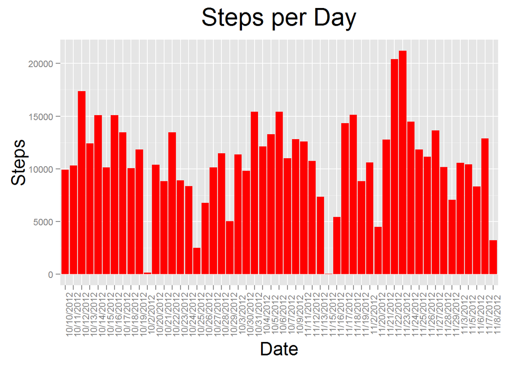

```r
library(ggplot2)
library(plyr)

ggplot(data = amdn, aes(x = date, y = steps)) + geom_histogram(fill = "red", stat = "identity") + theme(axis.text.x = element_text(angle = 90)) + xlab("Date") + ylab("Steps") + labs(title = "Steps per Day") + theme(plot.title = element_text(size = rel(2), vjust = 2)) + theme(axis.text = element_text(size = rel(.75))) + theme(axis.title = element_text(size = rel(1.5)))
```

```r
amdnm <- ddply(amdn,~date, summarize, mean=mean(steps),median=median(steps))
amdnm
```

```
##          date    mean median
## 1  10/10/2012 34.3750      0
## 2  10/11/2012 35.7778      0
## 3  10/12/2012 60.3542      0
## 4  10/13/2012 43.1458      0
## 5  10/14/2012 52.4236      0
## 6  10/15/2012 35.2049      0
## 7  10/16/2012 52.3750      0
## 8  10/17/2012 46.7083      0
## 9  10/18/2012 34.9167      0
## 10 10/19/2012 41.0729      0
## 11  10/2/2012  0.4375      0
## 12 10/20/2012 36.0938      0
## 13 10/21/2012 30.6285      0
## 14 10/22/2012 46.7361      0
```

[output cut: 39 more lines]

### Average Daily Activity

- Subset by interval and caculate mean
  - Plot mean activity by interval
  - Identify max mean interval

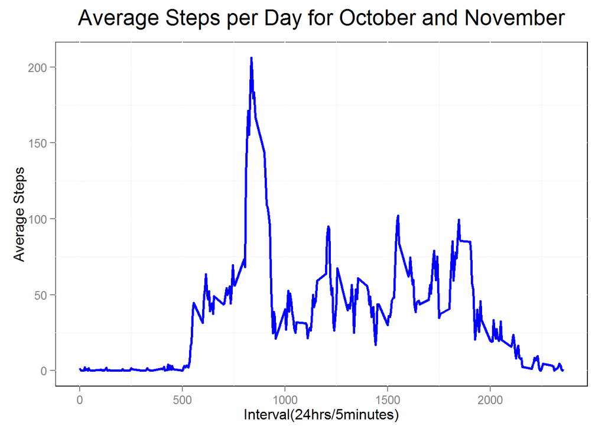

```r
ame <- ddply(amdn,~interval, summarize, mean=mean(steps))

ggplot(data = ame, aes(x = interval, y = mean)) + geom_line(size = 1, colour = "blue") + xlab("Interval(24hrs/5minutes)") + ylab("Average Steps") + labs(title = "Average Steps per Day for October and November") + theme(plot.title = element_text(size = rel(1.5), vjust = 2))+ theme(panel.background = element_rect(fill = "white", colour = "black"))
```

```r
subset(ame, mean == max(ame$mean))
```

```
##     interval  mean
## 104      835 206.2
```

### Imputing Missing Values

- Sum NA’s
- NA replacement strategy: use inerval means from ‘ame’ object to replace NA’s in corresponding interval with mean
  - Create column equalling ‘steps’ then input inverval means into NA’s with for loop
- Plot histogram
- Calculate mean and median of new data set with replaced NA’s

```r
sum(is.na(amd$steps))
```

```
## [1] 2304
```

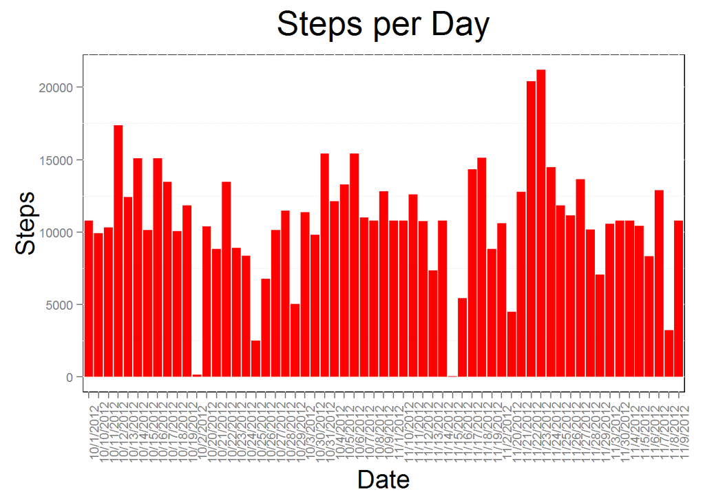

```r
amd$steps_imp <- amd$steps
for(i in 1:nrow(amd)){
    if(is.na(amd$steps[i])){
        amd$steps_imp[i] <- ame[ame$interval==amd$interval[i], 'mean']
    }
}

ggplot(data = amd, aes(x = date, y = steps_imp)) + geom_histogram(fill = "red", stat = "identity") + theme(axis.text.x = element_text(angle = 90)) + xlab("Date") + ylab("Steps") + labs(title = "Steps per Day") + theme(plot.title = element_text(size = rel(2), vjust = 2)) + theme(panel.background = element_rect(fill = "white", colour = "black")) + theme(axis.title=element_text(size=rel(1.5))) + theme(axis.text = element_text(size = rel(.75)))
```

```r
amedays <- ddply(amd,~date, summarize, mean=mean(steps_imp),median=median(steps_imp))
amedays
```

```
##          date    mean median
## 1   10/1/2012 37.3826  34.11
## 2  10/10/2012 34.3750   0.00
## 3  10/11/2012 35.7778   0.00
## 4  10/12/2012 60.3542   0.00
## 5  10/13/2012 43.1458   0.00
## 6  10/14/2012 52.4236   0.00
## 7  10/15/2012 35.2049   0.00
## 8  10/16/2012 52.3750   0.00
## 9  10/17/2012 46.7083   0.00
## 10 10/18/2012 34.9167   0.00
## 11 10/19/2012 41.0729   0.00
## 12  10/2/2012  0.4375   0.00
## 13 10/20/2012 36.0938   0.00
## 14 10/21/2012 30.6285   0.00
```

[output cut: 47 more lines]

*Summary Analysis of impact of imputing inverval means for NA’s + Means did not change + Where days with all NA’s replaced with mean intervals, median was 34.11; all other medians per day in both instances of monitoring where zero + NA replacement improves graphic appearance without skewing data summary

### Weekdays and Weekends

- Create factor with for loop
- Subset by factor and calculate mean
- Create panel plot seperated by factors weekday and weekend

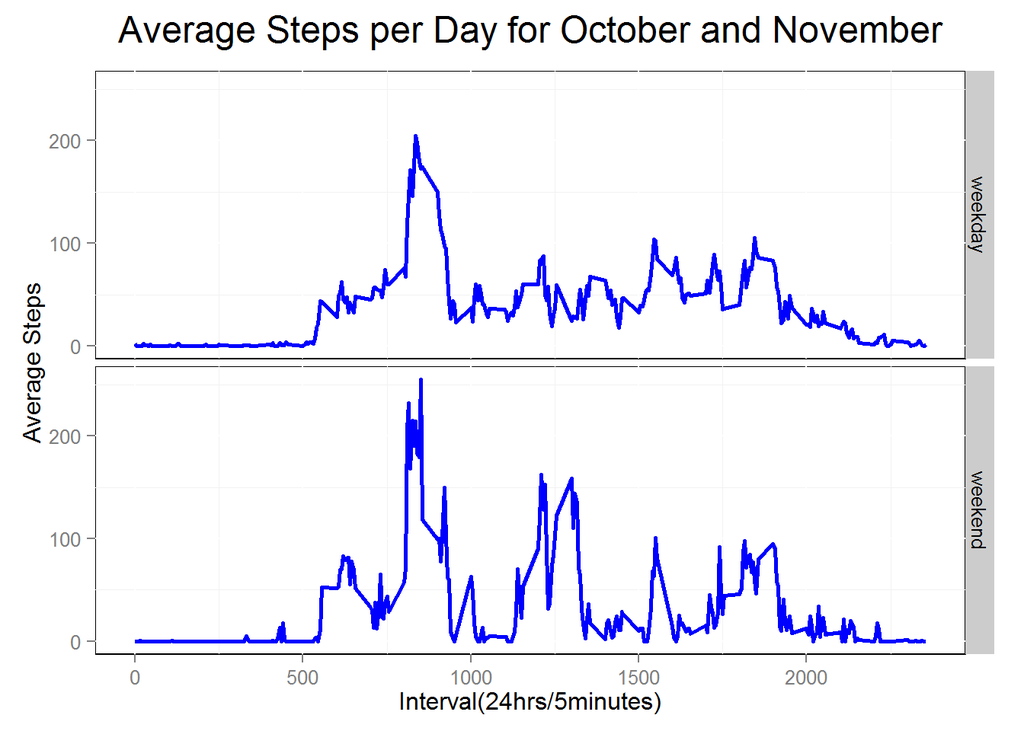

```r
amd$dates <- as.Date(amd$date)
for(i in 1:nrow(amd)){
    if(weekdays(amd$dates[i]) %in% c("Sunday", "Saturday")) {
        amd$day[i] <- "weekend"
    } else amd$day[i] <- "weekday"
}

amem <- ddply(amd, .(interval, day), summarize, mean=mean(steps_imp))

ggplot(data = amem, aes(x = interval, y = mean)) + geom_line(size = 1, colour = "blue") + xlab("Interval(24hrs/5minutes)") + ylab("Average Steps") + labs(title = "Average Steps per Day for October and November") + theme(plot.title = element_text(size = rel(1.5), vjust = 2))+ theme(panel.background = element_rect(fill = "white", colour = "black")) + facet_grid(day ~ .)
```